# Project2_C

Vishal Arora

Samriti Malhotra

3/10/2019

# Introduction :-

As part of project 2, this is the third messy data which needs to cleaned and tranformed to be ready to do the analysis.

## Problem Statment :-

This data set contains wine ratings of different varieties which are from different countries,the data has lot of blank values for wine points/country which needs to be cleaned and the data is mismanaged which needs to first sorted and arranged in way, before any meaningfull analysis can be done.

## Solution :-

We are using below libraries in our quest to resolve the above problem:- *knitr*  
*tidyr*  
*dplyr*  
*kableExtra*  
*ggplot2*

#### Steps performed on cleaning, tranforming and doing Analysis on the data

*1) Reading the data from local directory using read.csv function.*  
*2) Setting the blank data to NA and then we selected the relevant columns for our cleaning up and analysis using select function from tidy.*

```r
raw_df <- read.csv('winemag-data-130k-v2.csv', stringsAsFactors=F)
raw_df[raw_df==""] <- NA

wine_data <- select(raw_df , 2,5,6,7,13,14)
kable(head(wine_data)) %>%
  kable_styling(bootstrap_options = c("striped","hover","condensed","responsive"),full_width   = F,position = "left",font_size = 12) %>%
  row_spec(0, background ="gray")
```

| country | points | price | province | variety | winery |
| --- | --- | --- | --- | --- | --- |
| Italy | 87 | NA | Sicily & Sardinia | White Blend | Nicosia |
| Portugal | 87 | 15 | Douro | Portuguese Red | Quinta dos Avidagos |
| US | 87 | 14 | Oregon | Pinot Gris | Rainstorm |
| US | 87 | 13 | Michigan | Riesling | St. Julian |
| US | 87 | 65 | Oregon | Pinot Noir | Sweet Cheeks |
| Spain | 87 | 15 | Northern Spain | Tempranillo-Merlot | Tandem |

```r
wine_data <- wine_data %>%   drop_na(country)
wine_data_variety <- wine_data %>%
  group_by(country ) %>%
  summarise(avg_points = round(mean(points)))

kable(head(wine_data_variety)) %>%
  kable_styling(bootstrap_options = c("striped","hover","condensed","responsive"),full_width   = F,position = "left",font_size = 12) %>%
  row_spec(0, background ="gray")
```

| country | avg_points |
| --- | --- |
| Argentina | 87 |
| Armenia | 88 |
| Australia | 89 |
| Austria | 90 |
| Bosnia and Herzegovina | 86 |
| Brazil | 85 |

*6) Using the ggplot2 library we plot the average points against Country names to do our analysis.*

```
## geom_path: Each group consists of only one observation. Do you need to
## adjust the group aesthetic?
```

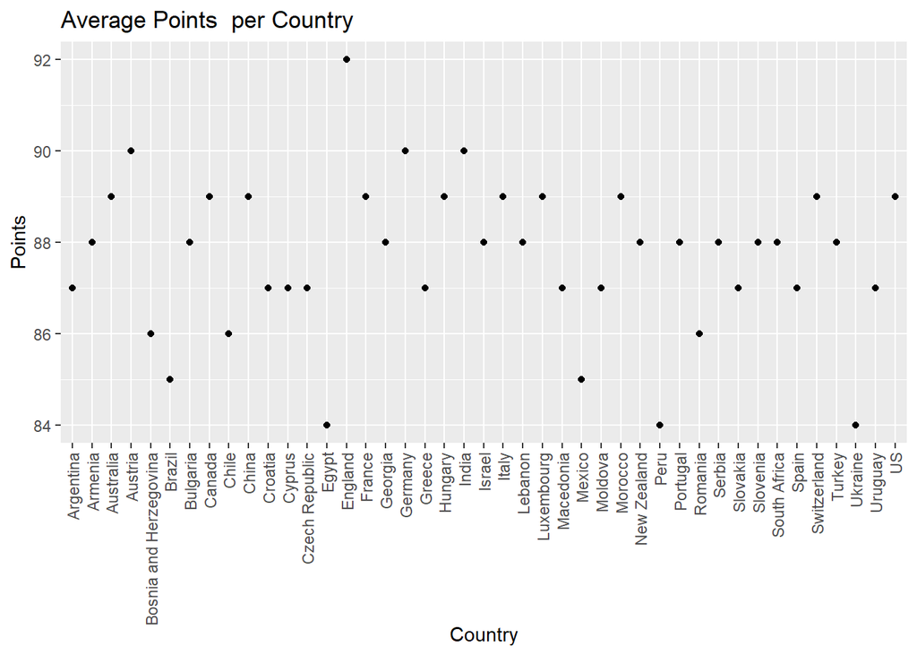

```r
wine_data_variety %>%
  ggplot(aes(x=country, y=avg_points)) +
  geom_point() + geom_line() +
  labs(title = "Average Points  per Country", x="Country", y="Points") +
  theme(axis.text.x=element_text(angle=90,hjust=1,vjust=0.5))
```

## Summary

Looking at the plotted graph we can say that the wines from England has been adjudged the best with 92 average wine tasting points, closely followed by Austria, Germany and India with 90 points. whereas Egypt,Peru and Ukraine wines have the least wine tasting average points.